# Lab4-LinearRegression[ameo-dataset]

## 16BCE1384

## Repository-link: https://github.com/raj1603chdry/CSE4020-MachineLearningLabs

### Importing the libraries

```python
import numpy as np
import pandas as pd
import seaborn as sns
import matplotlib.pyplot as plt
%matplotlib inline
from sklearn.linear_model import LinearRegression
from sklearn.model_selection import train_test_split
from sklearn.metrics import r2_score
from sklearn.metrics import mean_squared_error
```

### Loading the data

```python
X = pd.read_csv('../datasets/ameo_dataset/processed_dataset/X.csv')
X.head()
```

|  | 10percentage | 12percentage | collegeGPA | English | Logical | Quant | Domain | ComputerProgramming | ElectronicsAndSemicon | ComputerScience | ... | GraduationYear_2016 | GraduationYear_2017 | Gender_f | Gender_m | Degree_B.Tech/B.E. | Degree_M.Sc. (Tech.) | Degree_M.Tech./M.E. | Degree_MCA | CollegeTier_1 | CollegeTier_2 |
| --- | --- | --- | --- | --- | --- | --- | --- | --- | --- | --- | --- | --- | --- | --- | --- | --- | --- | --- | --- | --- | --- |
| 0 | 84.3 | 95.8 | 78.00 | 515 | 585 | 525 | 0.635979 | 445 | 0 | 0 | ... | 0 | 0 | 1 | 0 | 1 | 0 | 0 | 0 | 0 | 1 |
| 1 | 85.4 | 85.0 | 70.06 | 695 | 610 | 780 | 0.960603 | 0 | 466 | 0 | ... | 0 | 0 | 0 | 1 | 1 | 0 | 0 | 0 | 0 | 1 |
| 2 | 85.0 | 68.2 | 70.00 | 615 | 545 | 370 | 0.450877 | 395 | 0 | 0 | ... | 0 | 0 | 1 | 0 | 1 | 0 | 0 | 0 | 0 | 1 |
| 3 | 85.6 | 83.6 | 74.64 | 635 | 585 | 625 | 0.974396 | 615 | 0 | 0 | ... | 0 | 0 | 0 | 1 | 1 | 0 | 0 | 0 | 1 | 0 |
| 4 | 78.0 | 76.8 | 73.90 | 545 | 625 | 465 | 0.124502 | 0 | 233 | 0 | ... | 0 | 0 | 0 | 1 | 1 | 0 | 0 | 0 | 0 | 1 |

5 rows × 70 columns

```python
y = pd.read_csv('../datasets/ameo_dataset/processed_dataset/y_reg.csv')
y.head()
```

|  | Salary |
| --- | --- |
| 0 | 420000 |
| 1 | 500000 |
| 2 | 325000 |
| 3 | 1100000 |
| 4 | 200000 |

### Training Simple Linear Regression model

```python
X1 = X[['Quant']].values
```

##### from the experiment of decision tree, we found that the most important feature is Quant

```python
slr = LinearRegression()
slr.fit(X1, y)
```

```
LinearRegression(copy_X=True, fit_intercept=True, n_jobs=1, normalize=False)
```

### Visualising the learned model

```python
def lin_regplot(X, y, model):
    plt.scatter(X, y, c='lightblue')
    plt.plot(X, model.predict(X), color='red', linewidth=2)
    return
```

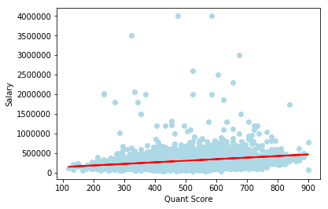

```python
lin_regplot(X1, y, slr)
plt.xlabel('Quant Score')
plt.ylabel('Salary')
plt.show()
```

#### From the plot above, we can see that a linear regression model is not able to predict the expected salary of the candidates accurately.

### Training the linear regresssion model on the training data and checking its performance on the test data

```python
X_train, X_test, y_train, y_test = train_test_split(
    X, y, test_size=0.3, random_state=42)
```

```python
slr = LinearRegression()
slr.fit(X_train,y_train)

y_train_pred = slr.predict(X_train)
y_test_pred = slr.predict(X_test)
```

```python
print('Train: %.3f \t Test: %.3f' % (
        mean_squared_error(y_train, y_train_pred),
        mean_squared_error(y_test, y_test_pred)))
```

```
Train: 35780318340.145 	 Test: 39469945138.427
```

```python
print('Train: %.3f \t Test: %.3f' % (
        r2_score(y_train, y_train_pred),
        r2_score(y_test, y_test_pred)))
```

```
Train: 0.186 	 Test: 0.182
```

#### From seeing the poor values of MSE and R2 score, we can conclude a linear regression model will not be able to predcit the salaries of the candidates accurately. The linear model makes very high error

### Checking the performance for differnet types of regression model

#### Using regularized linear regression model

```python
from sklearn.linear_model import Lasso

lasso = Lasso(alpha=0.01, max_iter = 1000000)
lasso.fit(X_train, y_train)
y_train_pred = lasso.predict(X_train)
y_test_pred = lasso.predict(X_test)
print(lasso.coef_)
```

```
[ 1.02673674e+03  1.10832174e+03  3.29147131e+03  1.62521879e+02
  1.10022349e+02  1.04110439e+02  2.29662648e+04  2.54101962e+01
 -6.12067747e+01 -4.15690793e+01  1.33779666e+02 -5.58373801e+01
  4.68942470e+00  3.23955118e+02 -1.32531285e+04  1.25237551e+04
  8.03178534e+03 -9.60259193e+03 -1.35489044e+04 -7.30388499e+04
  2.24590535e+04  2.23691009e+04 -1.52531979e+04 -3.93949321e+04
  5.64609950e-03  1.61160373e+04  1.39239840e+05 -1.02632593e+05
 -2.72714678e+03 -2.42908574e+04  2.05289040e+05 -2.76963736e+04
 -2.13024510e-02  3.13040555e+04  1.11129038e+04  1.35080604e+05
  1.90531938e+04 -9.18394011e+04  2.24873508e+04  2.32349175e+04
  1.60159431e+05 -1.54235528e+04 -7.32136030e+03 -1.68362536e+04
  2.19906664e+05 -3.81760250e+04 -3.67088446e+03 -1.34002054e+05
  6.75639270e+03  3.08534907e+04 -2.58107780e+04  0.00000000e+00
  0.00000000e+00  1.11470202e+05  1.27434842e+05  6.82550942e+04
  0.00000000e+00 -3.81619170e+04 -5.22017393e+04  1.91635512e+04
 -1.15910608e+04 -1.14963020e+05 -2.86947429e+04  0.00000000e+00
  1.24376481e+04  0.00000000e+00 -4.17499792e+03  0.00000000e+00
  8.05318176e+04 -5.33482258e-07]
```

```python
print('MSE train: %.3f, test: %.3f' % (
        mean_squared_error(y_train, y_train_pred),
        mean_squared_error(y_test, y_test_pred)))
print('R^2 train: %.3f, test: %.3f' % (
        r2_score(y_train, y_train_pred),
        r2_score(y_test, y_test_pred)))
```

```
MSE train: 35780318341.441, test: 39464365226.676
R^2 train: 0.186, test: 0.182
```

```python
from sklearn.linear_model import Lasso

lasso = Lasso(alpha=0.1, max_iter = 100000)
lasso.fit(X_train, y_train)
y_train_pred = lasso.predict(X_train)
y_test_pred = lasso.predict(X_test)
print(lasso.coef_)
```

```
[ 1.02674046e+03  1.10835449e+03  3.29135545e+03  1.62524987e+02
  1.10022095e+02  1.04112915e+02  2.29636515e+04  2.54154115e+01
 -6.11988617e+01 -4.15703454e+01  1.33764726e+02 -5.58376566e+01
  4.69188061e+00  3.23839256e+02 -1.32528179e+04  1.25236672e+04
  8.03187809e+03 -9.60222527e+03 -1.35487956e+04 -7.29734232e+04
  2.24637612e+04  2.23721070e+04 -1.52426990e+04 -3.93775755e+04
  5.64741928e-02  1.61115009e+04  1.39152323e+05 -1.02589628e+05
 -2.71676968e+03 -2.42884302e+04  2.05018817e+05 -2.76833631e+04
 -2.13038240e-01  3.12793558e+04  1.10600565e+04  1.35058828e+05
  1.90496821e+04 -9.18312941e+04  2.24840891e+04  2.32308644e+04
  1.60030580e+05 -1.54236850e+04 -7.32264224e+03 -1.68364059e+04
  2.19776990e+05 -3.81769489e+04 -3.67294944e+03 -1.33877492e+05
  6.75355375e+03  3.08472244e+04 -2.58111565e+04  0.00000000e+00
  0.00000000e+00  1.11453047e+05  1.27434272e+05  6.82539908e+04
  0.00000000e+00 -3.81620970e+04 -5.22004637e+04  1.91580312e+04
 -1.15275171e+04 -1.14925218e+05 -2.86937700e+04  3.09905165e-10
  1.24346599e+04  0.00000000e+00 -4.16782071e+03  0.00000000e+00
  8.05282831e+04 -8.21944811e-08]
```

```python
print('MSE train: %.3f, test: %.3f' % (
        mean_squared_error(y_train, y_train_pred),
        mean_squared_error(y_test, y_test_pred)))
print('R^2 train: %.3f, test: %.3f' % (
        r2_score(y_train, y_train_pred),
        r2_score(y_test, y_test_pred)))
```

```
MSE train: 35780318469.807, test: 39463945560.911
R^2 train: 0.186, test: 0.182
```

#### Using polynomial regression

```python
def curve_plots(X,y):
    regr = LinearRegression()
    # create polynomial features
    from sklearn.preprocessing import PolynomialFeatures
    quadratic = PolynomialFeatures(degree=2)
    cubic = PolynomialFeatures(degree=3)
    X_quad = quadratic.fit_transform(X)
    X_cubic = cubic.fit_transform(X)

    # linear fit
    from sklearn.metrics import r2_score
    X_fit = np.arange(X.min(), X.max(), 1)[:, np.newaxis]
    regr = regr.fit(X, y)
    y_lin_fit = regr.predict(X_fit)
    linear_r2 = r2_score(y, regr.predict(X))

    # quadratic fit
    regr = regr.fit(X_quad, y)
    y_quad_fit = regr.predict(quadratic.fit_transform(X_fit))
    quadratic_r2 = r2_score(y, regr.predict(X_quad))

    # cubic fit
    regr = regr.fit(X_cubic, y)
    y_cubic_fit = regr.predict(cubic.fit_transform(X_fit))
    cubic_r2 = r2_score(y, regr.predict(X_cubic))

    # plot results
    plt.scatter(X, y,label='training points',color='lightgray')
    plt.plot(X_fit, y_lin_fit,label='linear (d=1), $R^2=%.2f$'% linear_r2,color='blue',lw=2,linestyle=':')
    plt.plot(X_fit, y_quad_fit,label='quadratic (d=2), $R^2=%.2f$'% quadratic_r2,color='red',lw=2,linestyle='-')
    plt.plot(X_fit, y_cubic_fit,label='cubic (d=3), $R^2=%.2f$'% cubic_r2,color='green',lw=2,linestyle='--')
    plt.xlabel('Quant')
    plt.ylabel('Salary')
    plt.legend(loc='upper right')
    plt.show()
    return None
```

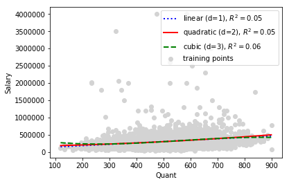

```python
curve_plots(X1, y)
```

#### The above polynomial regression curve for d = 1, 2 and 3, show that even polynomial features are not able to recognize the pattern in the dataset and all have a comparable R2 score 0f 0.05. The above problem could solved by using multivariate regression as with the help of more than 1 feature, it would be better able to recognize the pattern in the dataset.